# Descriptive statistics

Workshop on Statistics for Linguistics

Sky Onosson, University of Manitoba

## Agenda

- Descriptive statistics

## Load required packages and LIPP data

```r
if(!require(tidyverse)){install.packages("tidyverse")}
library(tidyverse)

if(!require(viridis)){install.packages("viridis")}
library(viridis)

LIPP <- read_csv("LIPP.csv")
```

# 1 Descriptive statistics

## 1.1 Boxplots and descriptive statistics

Let’s look at these two distributions in a boxplot. These are a type of plot used to highlight certain key aspects of a distribution. Boxplots expect to be provided one continuous variable (often plotted on the *y*-axis) and one categorical variable (on the *x*-axis) – sometimes, there may be just one set of data, in which case there is no categorical variable to divide the data by.

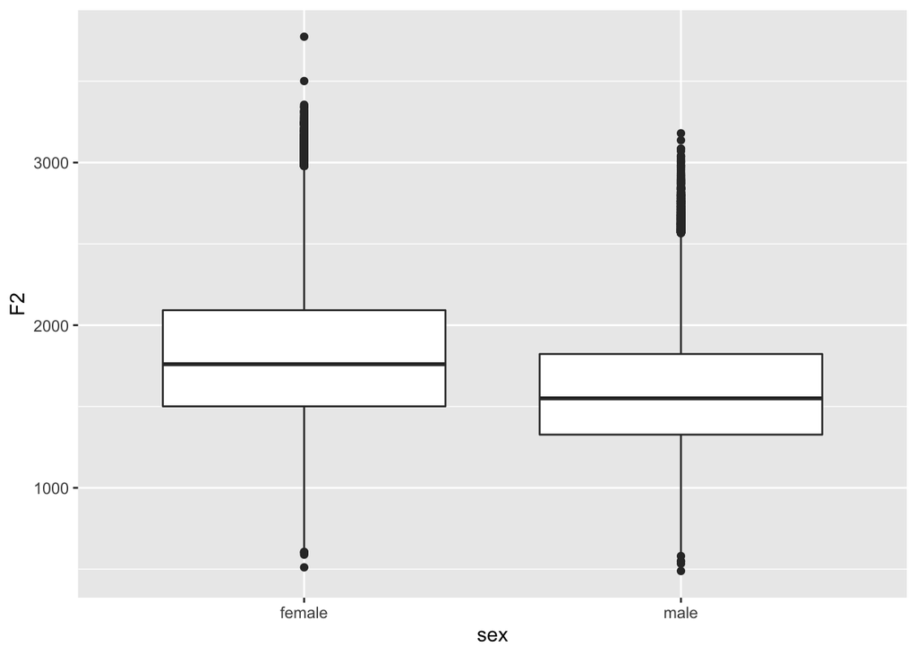

```r
ggplot(data = LIPP, aes(y = F2, x = sex)) +
  geom_boxplot()
```

What is indicated in the boxplot? The rectangular box itself contains the central 50% quantity of the distribution, and the central line indicates the median (not the mean!) value, i.e. the value exactly in the centre of the data. The two extended lines or “whiskers” mark the range of the distribution beyond which observations are considered to be “outliers”, which are marked with dots. The whiskers are each 1.5 times the distance of the box itself, i.e. 1.5 times the central 50% of the range (this is the interquartile range or IQR). Note that there appear to be a lot more high-frequency outliers than low-frequency ones, for both males and females.

Overall, the two distributions look pretty similar to each other, but the female speakers’ frequencies are shifted higher by 200-300 Hz. This both fits with our intuition and knowledge about sex-based speech differences, and our previous examination of the data.

By the way, if you just want to capture some of the basic numerical descriptors regarding your data, the `summary()` function is pretty useful. This provides statistical values including the minimum, maximum, median and mean values, as well as the 1st and 3rd quantiles, which define the outer boundaries of the box in a boxplot. If you just want the quantiles, `quantile()` gives you all of that except the mean – recall that the mean is actually not part of a boxplot, so this is a more accurate representation of the numerical data related to that type of plot.

```r
summary(LIPP$F2)
```

```
##    Min. 1st Qu.  Median    Mean 3rd Qu.    Max.
##   488.7  1415.2  1675.8  1722.0  1988.7  3773.9
```

```r
quantile(LIPP$F2)
```

```
##     0%    25%    50%    75%   100%
##  488.7 1415.2 1675.8 1988.7 3773.9
```

We can also look at our two sex/gender groups individually.

```r
summary(LIPP$F2[LIPP$sex == "male"])
```

```
##    Min. 1st Qu.  Median    Mean 3rd Qu.    Max.
##   488.7  1327.1  1550.1  1589.6  1822.8  3179.8
```

```r
summary(LIPP$F2[LIPP$sex == "female"])
```

```
##    Min. 1st Qu.  Median    Mean 3rd Qu.    Max.
##   511.1  1500.9  1760.1  1807.3  2092.1  3773.9
```

We can readily see that all of the values skew higher for the female speakers. This is the same result we saw in the boxplots earlier, put into numerical form. Personally, I rarely start with summarizing my data numerically like this, as I find a visual analysis far easier to grasp quickly. But numerical values are certainly useful and necessary in reporting your data later.

## 1.3 *t*-tests

Having observed earlier that the male & female speakers appear to have different F2 distributions, we might want to formally test this. A *t*-test is probably the simplest method for doing so, and is appropriate here because we are looking at one continuous variable, F2 values, across two groups. We provide it with the two sets of data for F2, split by speaker sex, and it determines whether there is reason to reject the null hypothesis, which would be the assumption that the two distributions are statistically identical. *t* values greater than +/- 1.96 are considered significant.

```r
t.test(x = LIPP$F2[LIPP$sex == "male"],
       y = LIPP$F2[LIPP$sex == "female"])
```

```
##
##  Welch Two Sample t-test
##
## data:  LIPP$F2[LIPP$sex == "male"] and LIPP$F2[LIPP$sex == "female"]
## t = -103.75, df = 152854, p-value < 2.2e-16
## alternative hypothesis: true difference in means is not equal to 0
## 95 percent confidence interval:
##  -221.8243 -213.5988
## sample estimates:
## mean of x mean of y
##  1589.603  1807.314
```

Because the *t* value is quite large and the *p* value is extremely small, we can comfortably reject the null hypothesis, and conclude that the LIPP male vs. female F2 distributions are substantially (*t* value) and significantly (*p* value) different from each other.